# Calculate Violations

Adam Dziorny

March 22, 2019

Include required packages.

```r
require(ggplot2)
require(scales)
require(dplyr)
require(svglite)
require(here)

# For publication level figures;
require(ggpubr)
require(cowplot)
```

Set the default extension for images:

```r
# Set default extension for output images
extension <- 'png'
```

## Import Data

```r
times.results <- read.csv(file = here::here('data', 'D_aggregate_violations.csv'))
```

## Duty Hours

First we compare violations by role, type and rotation. This can be done on the full calculated shifts dataset.

- Duration violations by role

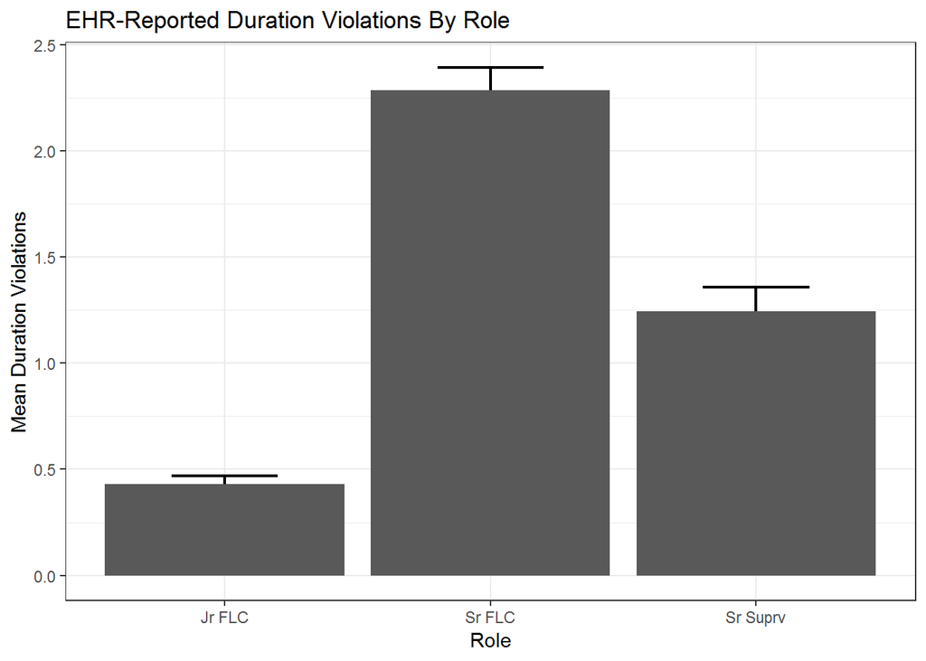

```r
img <-
  times.results %>%
  dplyr::select('ROLE','SOURCE','V_Durations') %>%
  dplyr::filter(SOURCE == 'ERS') %>%
  dplyr::group_by(ROLE) %>%
  dplyr::summarise(mean = mean(V_Durations),
                   sd = sd(V_Durations),
                   n = n(),
                   sem = sd(V_Durations)/sqrt(n())) %>%
  ggplot() +
  geom_errorbar( aes(x = ROLE, ymin = mean - sem, ymax = mean + sem), width = 0.4, size = 0.8) +
  geom_col( aes(ROLE, mean) ) +
  xlab('Role') +
  ylab('Mean Duration Violations') +
  ggtitle('EHR-Reported Duration Violations By Role') +
  theme_bw()

img
```

- ANOVA & Tukey Post-Hoc of Duration Violations by Role

```r
fit <- aov(V_Durations ~ ROLE, data =
  dplyr::select(times.results, 'ROLE','SOURCE','V_Durations') %>%
  dplyr::filter(SOURCE == 'ERS'))

summary(fit)
```

```
##              Df Sum Sq Mean Sq F value Pr(>F)
## ROLE          2  552.7  276.33   140.5 <2e-16 ***
## Residuals   768 1510.7    1.97
## ---
## Signif. codes:  0 '***' 0.001 '**' 0.01 '*' 0.05 '.' 0.1 ' ' 1
```

```r
TukeyHSD(fit)
```

```
##   Tukey multiple comparisons of means
##     95% family-wise confidence level
##
## Fit: aov(formula = V_Durations ~ ROLE, data = dplyr::select(times.results, "ROLE", "SOURCE", "V_Durations") %>% dplyr::filter(SOURCE == "ERS"))
##
## $ROLE
##                      diff        lwr        upr p adj
## Sr FLC-Jr FLC    1.854567  1.5946392  2.1144957 0e+00
## Sr Suprv-Jr FLC  0.813416  0.4707653  1.1560667 1e-07
## Sr Suprv-Sr FLC -1.041151 -1.3889681 -0.6933347 0e+00
```

```r
dplyr::select(times.results, 'ROLE','SOURCE','V_Durations') %>%
  dplyr::filter(SOURCE == 'ERS') %>%
  dplyr::group_by(ROLE) %>%
  dplyr::summarize(mean = mean(V_Durations),
                   median = median(V_Durations),
                   sem = sd(V_Durations) / sqrt(n()))
```

```
## # A tibble: 3 x 4
##   ROLE      mean median    sem
##   <fct>    <dbl>  <int>  <dbl>
## 1 Jr FLC   0.431      0 0.0400
## 2 Sr FLC   2.29       2 0.110
## 3 Sr Suprv 1.24       1 0.114
```

```r
rm(fit)
```

- Interval violations by role

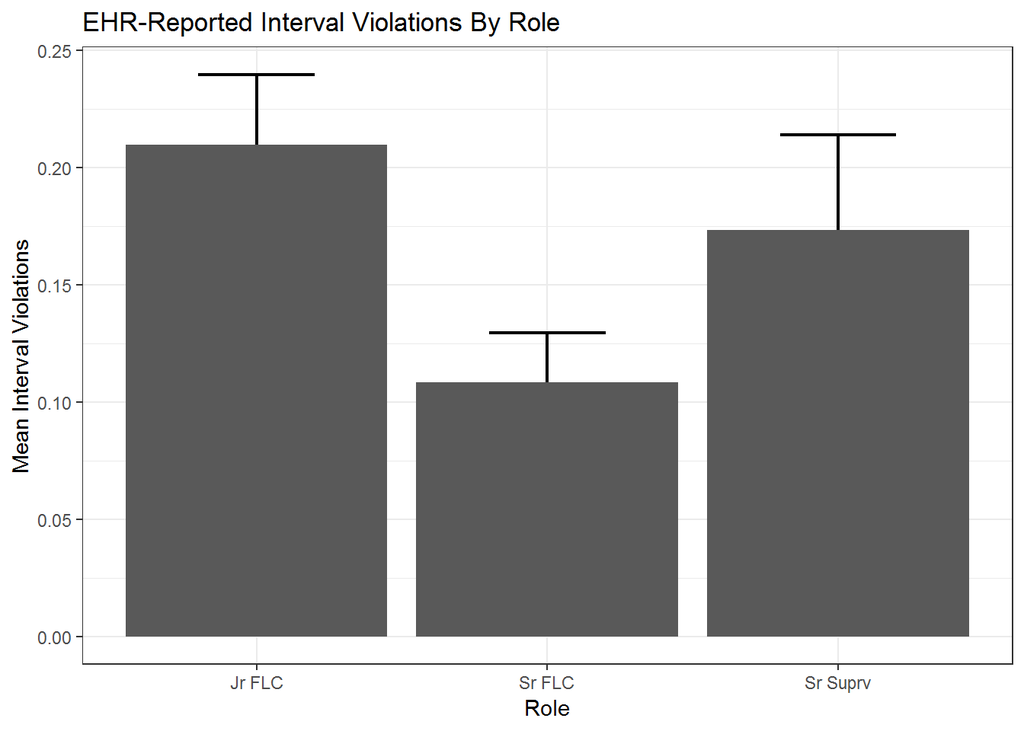

```r
img <-
  times.results %>%
  dplyr::select('ROLE','SOURCE','V_Intervals') %>%
  dplyr::filter(SOURCE == 'ERS') %>%
  dplyr::group_by(ROLE) %>%
  dplyr::summarise(mean = mean(V_Intervals),
                   sd = sd(V_Intervals),
                   n = n(),
                   sem = sd(V_Intervals)/sqrt(n())) %>%
  ggplot() +
  geom_errorbar( aes(x = ROLE, ymin = mean - sem, ymax = mean + sem), width = 0.4, size = 0.8) +
  geom_col( aes(ROLE, mean) ) +
  xlab('Role') +
  ylab('Mean Interval Violations') +
  ggtitle('EHR-Reported Interval Violations By Role') +
  theme_bw()

img
```

- ANOVA & Tukey post-hoc of Interval Violations by Role

```r
fit <- aov(V_Intervals ~ ROLE, data =
  dplyr::select(times.results, 'ROLE','SOURCE','V_Intervals') %>%
  dplyr::filter(SOURCE == 'ERS'))

summary(fit)
```

```
##              Df Sum Sq Mean Sq F value Pr(>F)
## ROLE          2   1.66  0.8301   3.712 0.0249 *
## Residuals   768 171.75  0.2236
## ---
## Signif. codes:  0 '***' 0.001 '**' 0.01 '*' 0.05 '.' 0.1 ' ' 1
```

```r
TukeyHSD(fit)
```

```
##   Tukey multiple comparisons of means
##     95% family-wise confidence level
##
## Fit: aov(formula = V_Intervals ~ ROLE, data = dplyr::select(times.results, "ROLE", "SOURCE", "V_Intervals") %>% dplyr::filter(SOURCE == "ERS"))
##
## $ROLE
##                        diff         lwr         upr     p adj
## Sr FLC-Jr FLC   -0.10124281 -0.18888338 -0.01360224 0.0186902
## Sr Suprv-Jr FLC -0.03621118 -0.15174344  0.07932108 0.7421472
## Sr Suprv-Sr FLC  0.06503163 -0.05224248  0.18230573 0.3943734
```

```r
dplyr::select(times.results, 'ROLE','SOURCE','V_Intervals') %>%
  dplyr::filter(SOURCE == 'ERS') %>%
  dplyr::group_by(ROLE) %>%
  dplyr::summarize(mean = mean(V_Intervals),
                   sem = sd(V_Intervals) / sqrt(n()))
```

```
## # A tibble: 3 x 3
##   ROLE      mean    sem
##   <fct>    <dbl>  <dbl>
## 1 Jr FLC   0.209 0.0301
## 2 Sr FLC   0.108 0.0211
## 3 Sr Suprv 0.173 0.0405
```

```r
rm(fit)
```

- Total Violations by Role

```r
dplyr::select(times.results, 'ROLE', 'SOURCE', 'V_Durations', 'V_Intervals') %>%
  dplyr::mutate(Violations = V_Durations + V_Intervals) %>%
  dplyr::filter(SOURCE == 'ERS') %>%
  dplyr::group_by(ROLE) %>%
  dplyr::summarise(sum.T = sum(Violations),
                   sum.V = sum(V_Durations),
                   sum.I = sum(V_Intervals))
```

```
## # A tibble: 3 x 4
##   ROLE     sum.T sum.V sum.I
##   <fct>    <int> <int> <int>
## 1 Jr FLC     217   146    71
## 2 Sr FLC     730   697    33
## 3 Sr Suprv   180   158    22
```

- Violations By Type & Role (Facets)

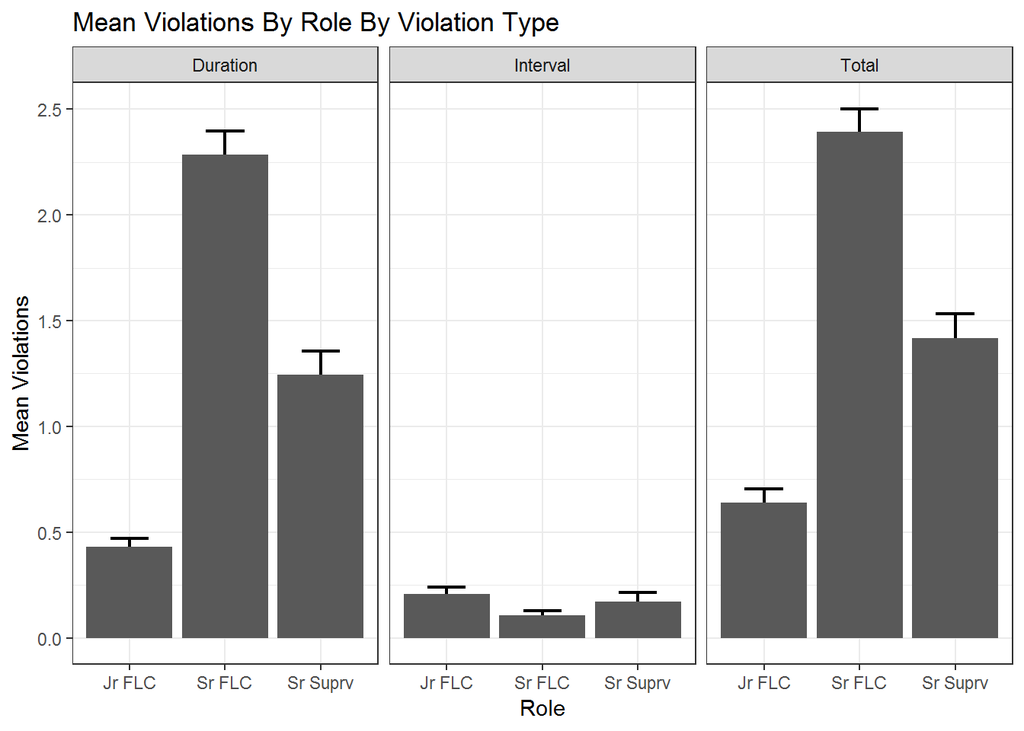

```r
viols.by.type <- rbind(
  # First include the Duration Violations
  dplyr::select(times.results, 'ROLE', 'SOURCE', 'V_Durations', 'V_Intervals') %>%
  dplyr::filter(SOURCE == 'ERS') %>%
  dplyr::group_by(ROLE) %>%
  dplyr::summarise(mean = mean(V_Durations),
                   sd = sd(V_Durations),
                   n = n(),
                   median = median(V_Durations),
                   sem = sd(V_Durations)/sqrt(n())) %>%
  dplyr::mutate(TYPE = 'Duration'),

  # Now include the Interval Violations
  dplyr::select(times.results, 'ROLE', 'SOURCE', 'V_Durations', 'V_Intervals') %>%
  dplyr::filter(SOURCE == 'ERS') %>%
  dplyr::group_by(ROLE) %>%
  dplyr::summarise(mean = mean(V_Intervals),
                   sd = sd(V_Intervals),
                   n = n(),
                   median = median(V_Intervals),
                   sem = sd(V_Intervals)/sqrt(n())) %>%
  dplyr::mutate(TYPE = 'Interval'),

  # And lastly include total violations (the sum of these two)
  dplyr::select(times.results, 'ROLE', 'SOURCE', 'V_Durations', 'V_Intervals') %>%
  dplyr::mutate(Violations = V_Durations + V_Intervals) %>%
  dplyr::filter(SOURCE == 'ERS') %>%
  dplyr::group_by(ROLE) %>%
  dplyr::summarise(mean = mean(Violations),
                   sd = sd(Violations),
                   n = n(),
                   median = median(Violations),
                   sem = sd(Violations)/sqrt(n())) %>%
  dplyr::mutate(TYPE = 'Total'))

viols.by.type$TYPE <- factor(viols.by.type$TYPE)

img <-
  viols.by.type %>%
  ggplot() +
  geom_errorbar( aes(x = ROLE, ymin = mean - sem, ymax = mean + sem), width = 0.4, size = 0.8) +
  geom_col( aes(ROLE, mean) ) +
  facet_grid(. ~ TYPE) +
  xlab('Role') +
  ylab('Mean Violations') +
  ggtitle('Mean Violations By Role By Violation Type')  +
  theme_bw()

img
```

- Violations By Rotation

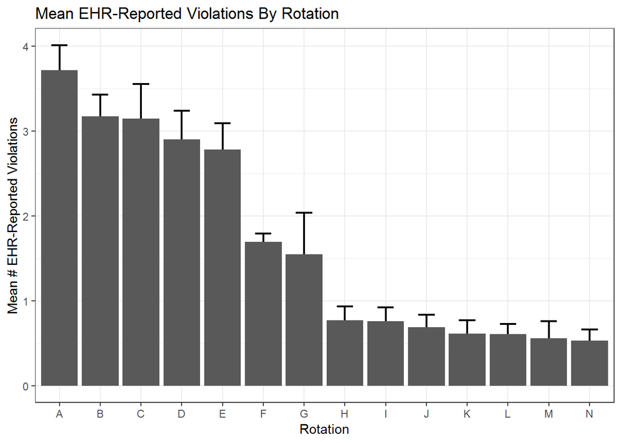

```r
viol.by.rot <-
  dplyr::select(times.results, c('ROLE', 'SOURCE', 'ROT_NM',
                                 'V_Durations', 'V_Intervals')) %>%
  dplyr::mutate(violations = V_Durations + V_Intervals) %>%
  dplyr::filter(SOURCE == 'ERS') %>%
  dplyr::filter(ROLE %in% c('Jr FLC', 'Sr FLC')) %>%
  dplyr::group_by(ROT_NM) %>%
  dplyr::summarise(mean = mean(violations),
                   sd = sd(violations),
                   n = n(),
                   sem = sd(violations)/sqrt(n())) %>%
  dplyr::arrange(-mean) %>%
  dplyr::mutate(orders = n() - row_number(mean) + 1,
                letters = LETTERS[1:n()][orders],
                ROT_NM = factor(ROT_NM,ROT_NM))

img <-
  viol.by.rot %>%
  ggplot() +
  geom_errorbar( aes(x = letters, ymin = mean - sem, ymax = mean + sem), width = 0.4, size = 0.8) +
  geom_col( aes(letters, mean) ) +
  theme_bw() +
  #theme(axis.text.x = element_text(angle = 45, hjust = 1)) +
  xlab('Rotation') +
  ylab('Mean # EHR-Reported Violations') +
  ggtitle('Mean EHR-Reported Violations By Rotation')

img
```

- ANOVA of Violations by Rotation

```r
fit <- aov(violations ~ ROT_NM, data =
  dplyr::select(times.results, c('ROLE', 'SOURCE', 'ROT_NM',
                                 'V_Durations', 'V_Intervals')) %>%
  dplyr::mutate(violations = V_Durations + V_Intervals) %>%
  dplyr::filter(SOURCE == 'ERS') %>%
  dplyr::filter(ROLE %in% c('Jr FLC', 'Sr FLC')))

summary(fit)
```

```
##              Df Sum Sq Mean Sq F value Pr(>F)
## ROT_NM       13  821.5   63.19   32.29 <2e-16 ***
## Residuals   630 1232.9    1.96
## ---
## Signif. codes:  0 '***' 0.001 '**' 0.01 '*' 0.05 '.' 0.1 ' ' 1
```

```r
dplyr::select(times.results, c('ROLE', 'SOURCE', 'ROT_NM',
                                 'V_Durations', 'V_Intervals')) %>%
  dplyr::mutate(violations = V_Durations + V_Intervals) %>%
  dplyr::filter(SOURCE == 'ERS') %>%
  dplyr::filter(ROLE %in% c('Jr FLC', 'Sr FLC')) %>%
  dplyr::group_by(ROT_NM) %>%
  dplyr::summarize(mean = mean(violations),
                   sem = sd(violations) / sqrt(n()))
```

```
## # A tibble: 14 x 3
##    ROT_NM  mean   sem
##    <fct>  <dbl> <dbl>
##  1 A      0.614 0.155
##  2 B      0.530 0.130
##  3 C      0.769 0.162
##  4 D      0.609 0.119
##  5 E      3.17  0.259
##  6 F      0.761 0.163
##  7 G      0.687 0.151
##  8 H      3.15  0.409
##  9 I      2.9   0.340
## 10 J      1.69  0.101
## 11 K      1.55  0.493
## 12 L      2.78  0.310
## 13 M      3.72  0.296
## 14 N      0.556 0.202
```

```r
rm(fit)
```

### Compare Violations By Source

When we are comparing violations across sources, we must remember that only a subset of Resident-Blocks had *any* logged New Innovations shifts. Therefore we will make the comparisons across only those resident-blocks - meaning the sample size of our `HADOOP` sourced shifts will be smaller than above.

```r
rb.count.ni <- matrix(nrow=1, ncol=length(levels(times.results$ROLE)))

for (i in seq_along(levels(times.results$ROLE))) {
  rb.count.ni[1,i] <- sum(times.results$ROLE == levels(times.results$ROLE)[i] &
                          times.results$SOURCE == 'SRS' &
                          times.results$NumShifts > 0)
}

knitr::kable(rb.count.ni, col.names = levels(times.results$ROLE))
```

| Jr FLC | Sr FLC | Sr Suprv |
| --- | --- | --- |
| 312 | 202 | 89 |

```r
rm(i)
```

To do this we need a new column in our `times.results` data frame, which specifies if the UID - role combination contained any shifts in the `SRS` data.

```r
valid.uid.roles <- rbind(
  data.frame(
    UID = times.results$UID[times.results$ROLE == 'Jr FLC' &
                              times.results$SOURCE == 'SRS' &
                              times.results$NumShifts > 0],
    ROLE = 'Jr FLC'),
   data.frame(
    UID = times.results$UID[times.results$ROLE == 'Sr FLC' &
                              times.results$SOURCE == 'SRS' &
                              times.results$NumShifts > 0],
    ROLE = 'Sr FLC'),
  data.frame(
    UID = times.results$UID[times.results$ROLE == 'Sr Suprv' &
                              times.results$SOURCE == 'SRS' &
                              times.results$NumShifts > 0],
    ROLE = 'Sr Suprv')
) %>%
  dplyr::mutate(IS_IN_NI = T)

# Verify that the counts in this table match the counts above:
valid.uid.roles %>%
  dplyr::group_by(ROLE) %>%
  dplyr::summarise(n = n())
```

```
## # A tibble: 3 x 2
##   ROLE         n
##   <fct>    <int>
## 1 Jr FLC     312
## 2 Sr FLC     202
## 3 Sr Suprv    89
```

Now that we have a list of valid UIDs by Role, we join this with our times.results data to get a column called IS_IN_NI:

```r
times.results <- dplyr::left_join(x = times.results, y = valid.uid.roles, by = c("UID", "ROLE"))
times.results$IS_IN_NI[is.na(times.results$IS_IN_NI)] <- F

table(times.results$IS_IN_NI)
```

```
##
## FALSE  TRUE
##   336  1206
```

Now that we have a variable flagging whether our resident-block-role combination has any shifts in the NI dataset, we can filter on this variable for subsequent analysis in this section.

- Violations By Role & Source (Facets)

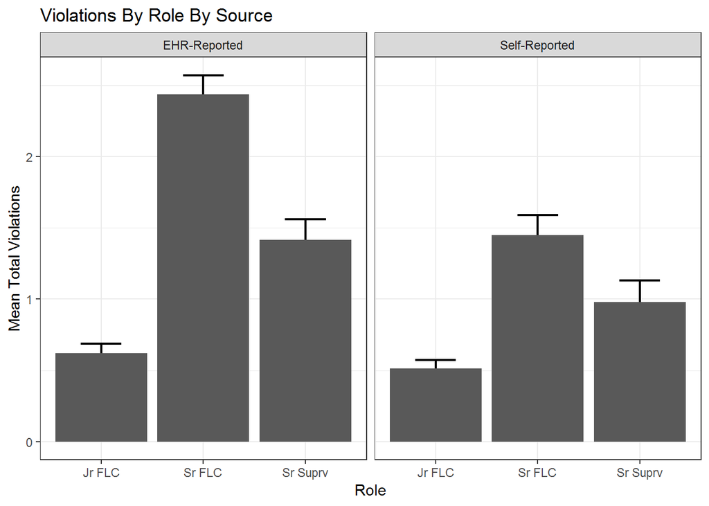

```r
viol.by.role.source <-
  dplyr::select(times.results, 'ROLE', 'SOURCE', 'IS_IN_NI', 'NumShifts', 'V_Durations', 'V_Intervals') %>%
  dplyr::filter(IS_IN_NI) %>%
  dplyr::mutate(Violations = V_Durations + V_Intervals) %>%
  dplyr::filter(NumShifts > 0) %>%
  dplyr::group_by(ROLE, SOURCE) %>%
  dplyr::summarise(mean = mean(Violations),
                   sd = sd(Violations),
                   n = n(),
                   median = median(Violations),
                   sem = sd(Violations)/sqrt(n()))

levels(viol.by.role.source$SOURCE) <- c('EHR-Reported', 'Self-Reported')

img <-
  viol.by.role.source %>%
  ggplot() +
  geom_errorbar( aes(x = ROLE, ymin = mean - sem, ymax = mean + sem), width = 0.4, size = 0.8) +
  geom_col( aes(ROLE, mean) ) +
  facet_grid(. ~ SOURCE) +
  xlab('Role') +
  ylab('Mean Total Violations') +
  ggtitle('Violations By Role By Source')  +
  theme_bw()

img
```

- GLM for Violations by Role and Source

```r
viol.glm <- glm(Violations ~ ROLE + SOURCE, data =
  dplyr::select(times.results, 'ROLE', 'SOURCE', 'IS_IN_NI', 'NumShifts', 'V_Durations', 'V_Intervals') %>%
  dplyr::filter(IS_IN_NI) %>%
  dplyr::mutate(Violations = V_Durations + V_Intervals) %>%
  dplyr::filter(NumShifts > 0))

summary(viol.glm)
```

```
##
## Call:
## glm(formula = Violations ~ ROLE + SOURCE, data = dplyr::select(times.results,
##     "ROLE", "SOURCE", "IS_IN_NI", "NumShifts", "V_Durations",
##     "V_Intervals") %>% dplyr::filter(IS_IN_NI) %>% dplyr::mutate(Violations = V_Durations +
##     V_Intervals) %>% dplyr::filter(NumShifts > 0))
##
## Deviance Residuals:
##     Min       1Q   Median       3Q      Max
## -2.1686  -0.7928  -0.3418   0.5778   7.2072
##
## Coefficients:
##              Estimate Std. Error t value Pr(>|t|)
## (Intercept)   0.79285    0.07393  10.724  < 2e-16 ***
## ROLESr FLC    1.37576    0.09574  14.370  < 2e-16 ***
## ROLESr Suprv  0.62932    0.12739   4.940 8.92e-07 ***
## SOURCESRS    -0.45108    0.08634  -5.224 2.06e-07 ***
## ---
## Signif. codes:  0 '***' 0.001 '**' 0.01 '*' 0.05 '.' 0.1 ' ' 1
##
## (Dispersion parameter for gaussian family taken to be 2.247617)
##
##     Null deviance: 3228.3  on 1205  degrees of freedom
## Residual deviance: 2701.6  on 1202  degrees of freedom
## AIC: 4405.2
##
## Number of Fisher Scoring iterations: 2
```

- Violations reported minus calculated

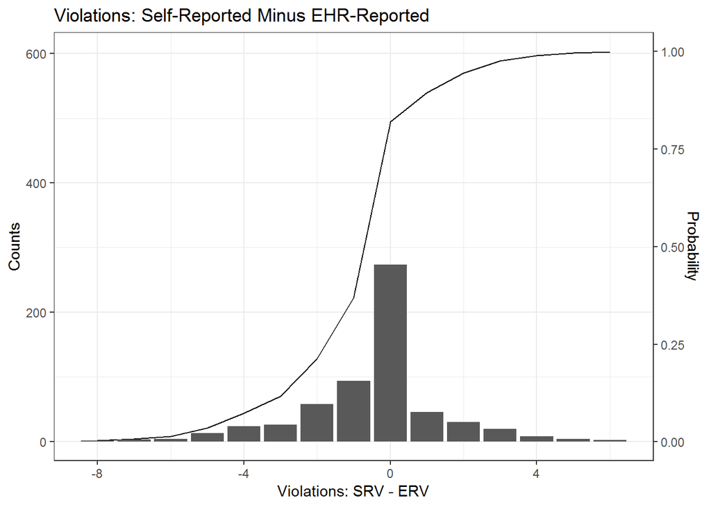

```r
viol.hadoop <-
  dplyr::select(times.results, 'UID','NumShifts','IS_IN_NI','V_Durations','V_Intervals','SOURCE', 'ROLE') %>%
  dplyr::filter(IS_IN_NI) %>%
  dplyr::filter(NumShifts > 0) %>%
  dplyr::mutate(Violations = V_Durations + V_Intervals) %>%
  dplyr::filter(SOURCE == 'ERS')

viol.ni <-
  dplyr::select(times.results, 'UID','NumShifts','IS_IN_NI','V_Durations','V_Intervals','SOURCE', 'ROLE') %>%
  dplyr::filter(IS_IN_NI) %>%
  dplyr::filter(NumShifts > 0) %>%
  dplyr::mutate(Violations = V_Durations + V_Intervals) %>%
  dplyr::filter(SOURCE == 'SRS')

viol.combined <-
  dplyr::inner_join(x = viol.hadoop, y = viol.ni, by = c('UID', 'ROLE'), suffix = c('.hadoop', '.ni')) %>%
  dplyr::mutate(diff = Violations.ni - Violations.hadoop) %>%
  dplyr::group_by(diff) %>%
  dplyr::summarise(cnt = n()) %>%
  dplyr::mutate(cumcnt = cumsum(cnt),
                cnt = cnt )

scale.factor <- sum(viol.combined$cnt)

img <-
  viol.combined %>%
  ggplot() +
  geom_line( aes(diff, cumcnt) ) +
  geom_col( aes(diff, cnt)) +
  scale_y_continuous(limits = c(0, scale.factor), sec.axis = sec_axis(~ . / scale.factor, name='Probability')) +
  xlab('Violations: SRV - ERV') +
  ylab('Counts') +
  ggtitle('Violations: Self-Reported Minus EHR-Reported') +
  theme_bw()

img
```

- Numerics of calculated shifts for results section

```r
data.frame (
  diff = viol.combined$diff,
  perc = viol.combined$cumcnt /
    sum(viol.combined$cnt),
  cnt = viol.combined$cumcnt
)
```

```
##    diff        perc cnt
## 1    -8 0.001658375   1
## 2    -7 0.006633499   4
## 3    -6 0.013266998   8
## 4    -5 0.034825871  21
## 5    -4 0.072968491  44
## 6    -3 0.116086235  70
## 7    -2 0.212271973 128
## 8    -1 0.368159204 222
## 9     0 0.820895522 495
## 10    1 0.895522388 540
## 11    2 0.945273632 570
## 12    3 0.976782753 589
## 13    4 0.990049751 597
## 14    5 0.996683250 601
## 15    6 1.000000000 603
```

## Make Publication Figures

### Figure 1

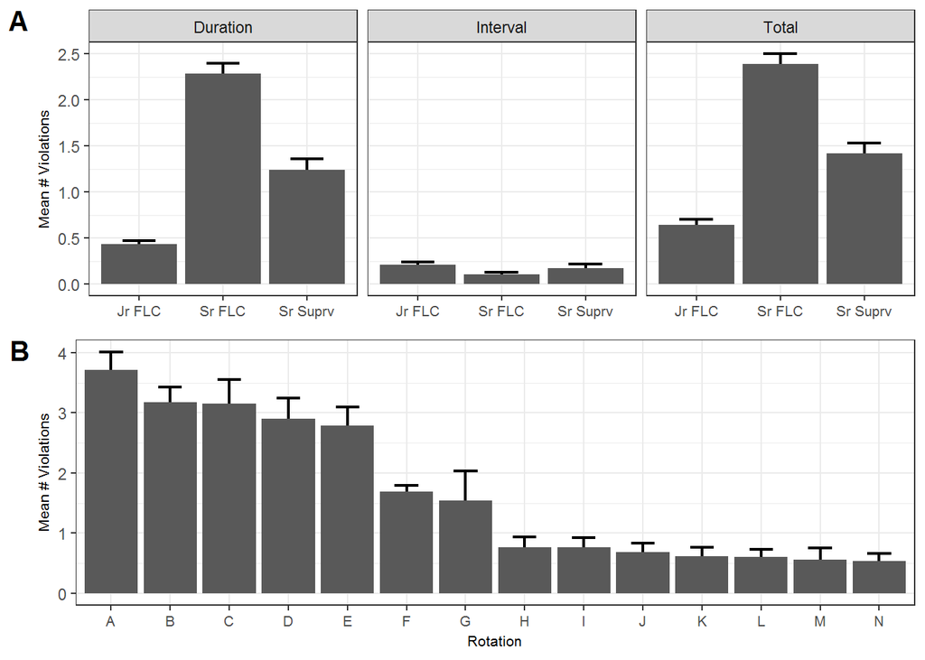

```r
A <-
  viols.by.type %>%
  ggplot() +
  geom_errorbar( aes(x = ROLE, ymin = mean - sem, ymax = mean + sem), width = 0.4, size = 0.8) +
  geom_col( aes(ROLE, mean) ) +
  facet_grid(. ~ TYPE) +
  ylab('Mean # Violations') +
  theme_bw() +
  theme(axis.title.x = element_blank(),
        axis.text.x = element_text(size = 8),
        axis.title.y = element_text(size = 8))

B <-
  viol.by.rot %>%
  ggplot() +
  geom_errorbar( aes(x = letters, ymin = mean - sem, ymax = mean + sem), width = 0.4, size = 0.8) +
  geom_col( aes(letters, mean) ) +
  xlab('Rotation') +
  theme_bw() +
  ylab('Mean # Violations') +
  theme(axis.title.x = element_text(size = 8),
        axis.text.x = element_text(size = 8),
        axis.title.y = element_text(size = 8))

fig2 <-
  ggdraw() +
  draw_plot(A, x = 0.03, y = 0.5, width = 0.97, height = 0.5, scale = 1) +
  draw_plot(B, x = 0.03, y = 0, width = 0.97, height = 0.5, scale = 1) +
  draw_plot_label(label = c('A', 'B'), size = 15,
                  x = c(0, 0), y = c(1, 0.5))

fig2
```

```r
cowplot::ggsave(filename = here::here('images', 'figure_1.png'),
                plot = fig2,
                dpi = 600,
                width = 7, height = 5, units = 'in')

rm(fig2,A,B)
```

### Figure 2

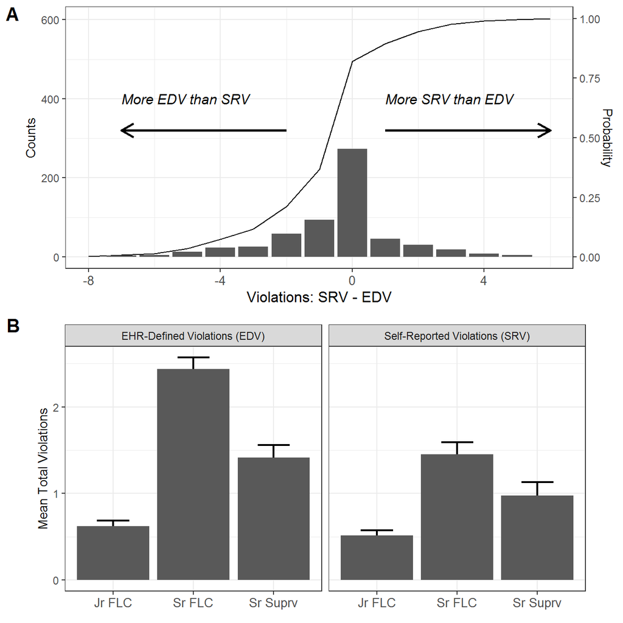

```r
levels(viol.by.role.source$SOURCE) <- c('EHR-Defined Violations (EDV)', 'Self-Reported Violations (SRV)')

A <-
  viol.by.role.source %>%
  ggplot() +
  geom_errorbar( aes(x = ROLE, ymin = mean - sem, ymax = mean + sem), width = 0.4, size = 0.8) +
  geom_col( aes(ROLE, mean) ) +
  facet_grid(. ~ SOURCE) +
  ylab('Mean Total Violations') +
  theme_bw() +
  theme(axis.title.x = element_blank(),
        axis.text.x = element_text(size = 10),
        axis.title.y = element_text(size = 10))

B <-
  viol.combined %>%
  ggplot() +
  geom_line( aes(diff, cumcnt) ) +
  geom_col( aes(diff, cnt)) +
  scale_y_continuous(limits = c(0, scale.factor), sec.axis = sec_axis(~ . / scale.factor, name='Probability')) +
  scale_x_continuous(limits = c(-8, 6)) +
  xlab('Violations: SRV - EDV') +
  ylab('Counts') +
  theme_bw() +
  theme(axis.title.x = element_text(size = 12),
        axis.text.x = element_text(size = 10),
        axis.title.y = element_text(size = 10)) +
  annotate('text', x = -7, y = 400, hjust = 0,
           label = 'More EDV than SRV', fontface = 3, size = 4) +
  annotate('text', x = 1, y = 400, hjust = 0,
           label = 'More SRV than EDV', fontface = 3, size = 4) +
  geom_segment(aes(x = -2, y = 320, xend = -7, yend = 320),
               colour='black', size=1, arrow = arrow(length = unit(0.4, "cm"))) +
  geom_segment(aes(x = 1, y = 320, xend = 6, yend = 320),
               colour='black', size=1, arrow = arrow(length = unit(0.4, "cm")))

fig3 <-
  ggdraw() +
  draw_plot(A, x = 0.03, y = 0, width = 0.94, height = 0.5, scale = 0.96) +
  draw_plot(B, x = 0.03, y = 0.5, width = 0.97, height = 0.5, scale = 1) +
  draw_plot_label(label = c('A', 'B'), size = 15,
                  x = c(0, 0), y = c(1, 0.5))

fig3
```

```r
cowplot::ggsave(filename = here::here('images', 'figure_2.png'),
                plot = fig3,
                dpi = 600,
                width = 7, height = 7, units = 'in')

rm(fig3,A,B)
```